# Chapter 1 - Linear Models

Author: Rick Dean

Article date: 2021-03-13

Abstract

The following are notes, graphics, and R scripts from the text [Generalized Additive Models, An Introduction with R, Second Edition](https://www.routledge.com/Generalized-Add-itive-Models-An-Introduction-with-R-Second-Edition/Wood/p/book/9781498728331) by Simon N. Wood.

```r
library(knitr)
library(kableExtra)
library(data.table)
library(gamair)
library(RplotterPkg)
library(RregressPkg)
```

## 1.3 The theory of linear models

### 1.3.1 Least squares estimation of $\beta$

We will be using the `gamair::sperm.comp1` data set to illustrate the derivartion.

1. Load the data and define the predictor(**X**) and response(**Y**) matrices:

```r
data("sperm.comp1", package = "gamair")
sperm1_dt <- data.table::setDT(sperm.comp1)
data.table::setnames(sperm1_dt,c("time.ipc","prop.partner"), c("time_ipc","prop_partner"))

n = 15
p = 3 # including the intercept

intercept_dt <- data.table(Intercept = 1)
X_dt <- sperm1_dt[, .(time_ipc, prop_partner)]
X_dt <- cbind(intercept_dt, X_dt)

X_mt <- as.matrix(X_dt)
Y_mt <- as.matrix(sperm1_dt[, .(count)])
```

2. Perform QR factorization using a defined function:

```r
get_qr <- function(X, complete = FALSE){
  A <- X
  n <- nrow(A)
  p <- ncol(A)
  Q <- diag(n)

  for(k in 1:p){
    # extract the kth column of the matrix
    col <- A[k:n, k]
    # calculation of the norm of the column in order to create the vector r
    norm1 <- sqrt(drop(crossprod(col)))
    # calculate the reflection vector  a_r
    a_r <- col
    a_r[1] <- a_r[1] + sign(a_r[1]) * norm1
    # beta <- 2 / ||a_r||^2
    beta <- 2 / drop(crossprod(a_r))
    # update matrix Q (trailing matrix only) by Householder reflection
    Q[,k:n] <- Q[,k:n] - tcrossprod(Q[,k:n] %*% a_r, beta * a_r)
    # update matrix A (trailing matrix only) by Householder reflection
    A[k:n, k:p] <- A[k:n,k:p] - tcrossprod(beta * a_r, crossprod(A[k:n,k:p], a_r))
  }

  if(complete){
    #A[lower.tri(A)] <- 0
    R <- A[1:p, ]
    R[lower.tri(R)] <- 0
    return(list(Q = Q, R = R))
  }else{
    R <- A[1:p, ]
    R[lower.tri(R)] <- 0
    return(list(Q = Q[,1:p], R = R))
  }
}


qr_fun_lst <- get_qr(X = X_mt, complete = T)
Q_mt <- qr_fun_lst$Q
R_mt <- qr_fun_lst$R
```

2. Decompose **X** and assign **Q**, **Qf** and **R** (Equation 1.5 page 12): **Qf** is an n x p orthogonal matrix; **R** is a p x p upper trianglar matrix

```r
# decompose X
# qr_lst <- base::qr(X_mt)
#
# Qf_mt <- base::qr.Q(qr_lst) # n x p
# R_mt <- base::qr.R(qr_lst) # p x p
#
# X_check_mt <- Qf_mt %*% R_mt  # Equation 1.5 page 12
#
# Q_mt <- base::qr.Q(qr_lst, complete = T) # orthogonal matrix n x n
# Q_check_mt <- t(Q_mt) %*% Q_mt # should get identity matrix
```

3. Compute the t(**Q**) * **Y** and assign vectors **f** and **r**:

```r
#tQY_mt <- base::qr.qty(qr_lst, Y_mt)

tQY_mt <- t(Q_mt) %*% Y_mt

f_v <- tQY_mt[1:p,]   # p
r_v <- tQY_mt[(p+1):n,] # n - p
```

4. Estimate the $\beta$’s (Equation 1.6 page 12):

```r
R_inv_mt <- solve(R_mt) # p x p
beta_hat_v <- (R_inv_mt %*% f_v)[,1] # p x 1

# alternative
#beta_hat_v_alt <- (base::qr.coef(qr_lst, Y_mt))[,1]
```

5. Compute residual sum of squares:

```r
sse <- (t(r_v) %*% r_v)[1,1]

#resid_mt <- base::qr.resid(qr_lst, Y_mt)
#sse_alt <- (t(resid_mt) %*% resid_mt)[1,1]
```

### 1.3.2 The distribution of $\hat{\beta}$

### 1.3.3 $(\hat{\beta_{i}} - \beta_{i})/\hat{\sigma}_{\hat{\beta_{i}}} \sim t_{n-p}$

1. Estimate $\sigma^2$ (Equation 1.8 page 13):

```r
sigma_sq <- (t(r_v) %*% r_v)[1,1]/(n - p)
```

2. Compute covariance matrix of $\hat{\sigma}$ (Equation 1.7 page 13):

```r
var_cov_beta <- R_inv_mt %*% t(R_inv_mt) * sigma_sq # p x p
```

3. Compute the standard error of $\hat{\sigma}$ (page 14)

```r
var_beta_v <- diag(var_cov_beta)
se_beta_v <- sqrt(var_beta_v)
```

### 1.3.4 $F$-ratio results

Testing if $\beta_{time_ipc}$ and $\beta_{prop_partner}$ = 0 (i.e. **$\beta_{1}$** = 0)

$H_{0}:\beta_{1} = 0$ versus $H_{1}: \beta_{1} \ne 0$

1. Partition **X** into **X_0** and **X_1**:

```r
p = 3
q = 2

X_0_mt <- X_mt[,1]
X_1_mt <- X_mt[,2:3]
```

2. Partition **f** and compute the increase in residual sum of squares that results from dropping **X_1**:

```r
f_0_v <- f_v[1]
f_1_v <- f_v[2:3]

sse_minus_beta_1 <- (t(f_1_v) %*% f_1_v)[1,1]
```

3. Compute $F$ which follows an $F$ distribution with *q* (2) and *n - p* (12) degrees of freedom:

```r
F_val <- (sse_minus_beta_1/q)/sigma_sq
```

4. Compute the $F$ critical value with 2 and 12 df at 1% level

```r
F_cv <- qf(1 - 0.01, 2,12)
```

## 1.5 Practical linear modeling

### 1.5.1 Model fitting and model checking

#### 1.5.1.1 Loading the data

```r
data("sperm.comp1")
sperm1_dt <- data.table::setDT(sperm.comp1)
data.table::setnames(sperm1_dt, c("time.ipc", "prop.partner"), c("time_ipc", "prop_partner"))
```

#### 1.5.1.2 Plot the raw data

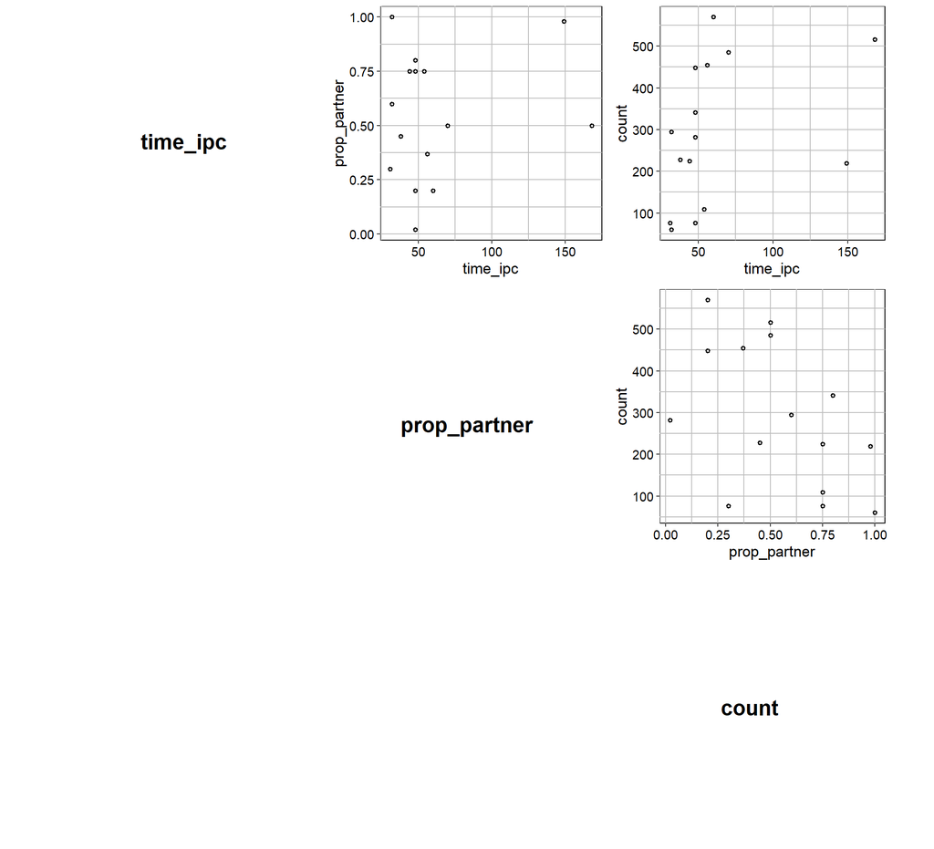

```r
RregressPkg::plot_matrix_scatter(
  df = sperm1_dt[,!c("subject")],
  rot_y_tic_label = T,
  plot_dim = 10
)
```

Take Away: There appears to some decrease in sperm count (*count*) as proportion of time spent together increases (*prop.partner*)

#### 1.5.1.3 Initial OLS model

```r
sperm_model_1_dt <- RregressPkg::ols_calc(
  df = sperm1_dt[,!c("subject")],
  formula_obj = count ~ time_ipc + prop_partner
)
RplotterPkg::create_table(
  x = sperm_model_1_dt$coef_df
)
```

| Coef | Value | SE | t_value | p_Value |
| --- | --- | --- | --- | --- |
| (Intercept) | 357.418434 | 88.0821592 | 4.057785 | 0.001588001 |
| time_ipc | 1.941609 | 0.9067154 | 2.141366 | 0.053460688 |
| prop_partner | -339.560170 | 126.2534581 | -2.689512 | 0.019687611 |

```r
model_1_lm <- lm(count ~ time_ipc + prop_partner, data = sperm1_dt)
summary(model_1_lm)
```

```
##
## Call:
## lm(formula = count ~ time_ipc + prop_partner, data = sperm1_dt)
##
## Residuals:
##      Min       1Q   Median       3Q      Max
## -239.740  -96.772    2.171   96.837  163.997
##
## Coefficients:
##               Estimate Std. Error t value Pr(>|t|)
## (Intercept)   357.4184    88.0822   4.058  0.00159 **
## time_ipc        1.9416     0.9067   2.141  0.05346 .
## prop_partner -339.5602   126.2535  -2.690  0.01969 *
## ---
## Signif. codes:  0 '***' 0.001 '**' 0.01 '*' 0.05 '.' 0.1 ' ' 1
##
## Residual standard error: 136.6 on 12 degrees of freedom
## Multiple R-squared:  0.4573, Adjusted R-squared:  0.3669
## F-statistic: 5.056 on 2 and 12 DF,  p-value: 0.02554
```